# HW 5

KaizeYi

9/21/2020

```r
library(ggplot2)
```

You still have formatting problems here: Because you did not leave a space between ## and “PROBLEM 1”, it is not formatted like a header. Be sure to leave a space between ## and the name of the header.

##PROBLEM 1

```r
library(here)
library(tidyverse)
```

```r
historical_path <- here("historical_guide.csv")
history <- read_csv(historical_path,
                    col_types = cols(
                      Year = col_integer(),
                      Stages = col_integer(),
                      Started = col_integer(),
                      Ended = col_integer(),
                      Distance = col_integer(),
                      Hour = col_integer(),
                      Minutes = col_integer(),
                      Seconds = col_integer(),
                      Pace = col_double(),
                      Winner = col_character(),
                      Country = col_character(),
                      Age= col_integer()
                      )
                    )
```

Pace should be double, because there is fraction for pace.

So… did you change the Pace variable to double? What was it before? What happened with it?

##Problem 2

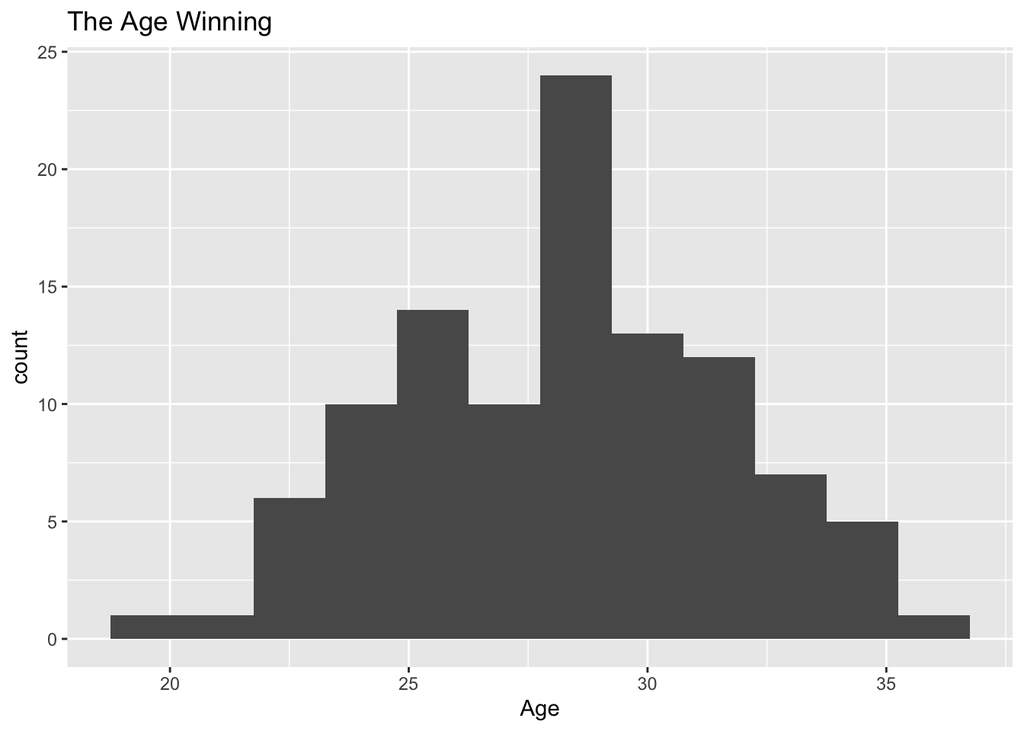

```r
  ggplot(history)+
    geom_histogram(mapping = aes(x = Age), binwidth = 1.5)+
    labs(title = "The Age Winning")
```

most of the cyclist win tour de France at their late 20s age

I thought for a moment we might be getting something bimodal here, but I think it might be an artifact. It’s possible this binwidth is a little too granular–there are not a lot of winners in any age bracket. Take a look at the ages with 10 or more winners:

```r
history %>%
  count(Age) %>%
  filter(n >= 10)
```

```
## # A tibble: 5 x 2
##     Age     n
##   <int> <int>
## 1    24    10
## 2    27    10
## 3    28    14
## 4    29    10
## 5    30    13
```

##problem 3

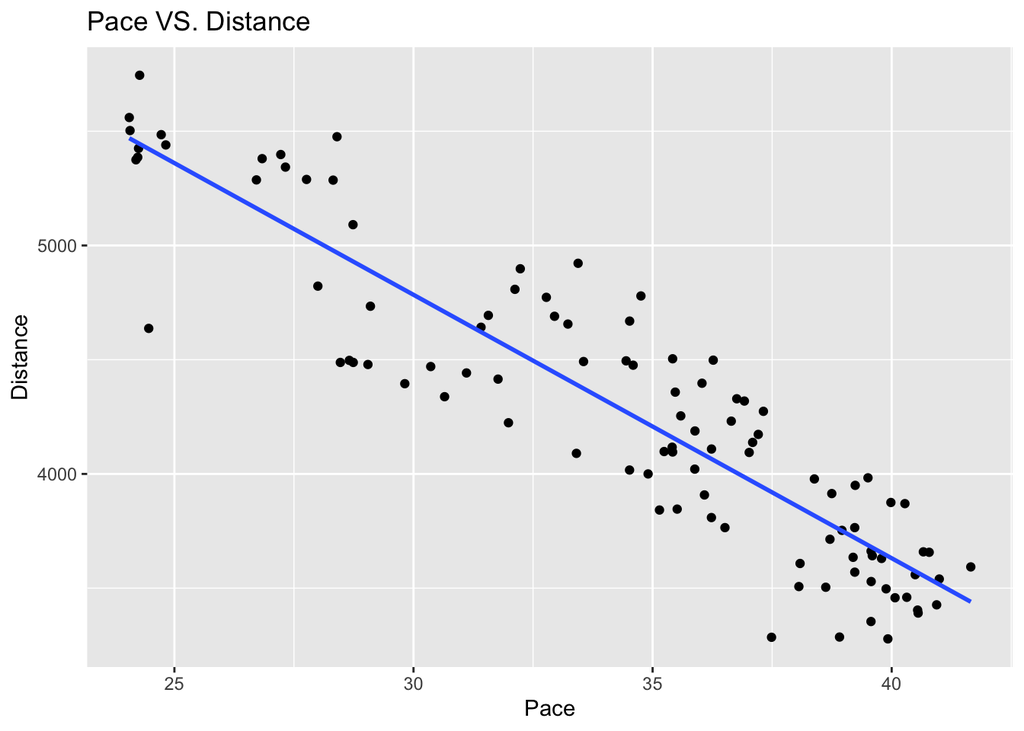

```r
history%>%
  filter(Distance > 3000)%>%
  ggplot(mapping = aes(x = Pace, y = Distance))+
  geom_point()+
  geom_smooth(method = "lm", se=FALSE)+
  labs(title = "Pace VS. Distance")
```

I find out that as the Distance decrease, pace increase. (formula for pace: min/km) In the early Tour de France, the distance is too short. It’s below 3000 km, I cleaned it out.

Ah, I think this is kind of interesting, and it makes sense.

I’m wondering about those filtered points (1903-1905). It’s odd that these much shorter distances also resulted in very low pace times–it feels like something weird is going on here. I’m also curious about why the distances started smaller, leapt upward, and seem to be declining since then:

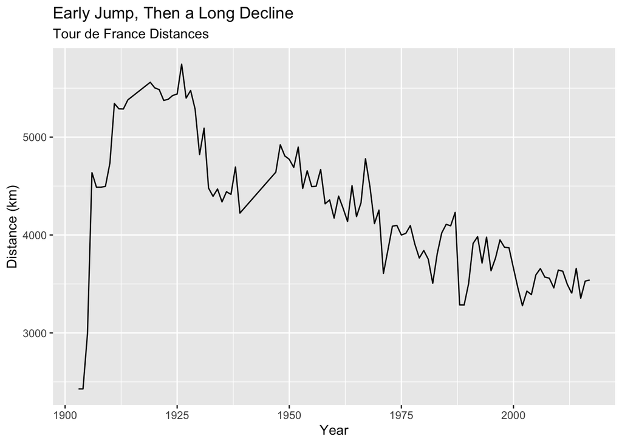

```r
ggplot(history, aes(x = Year, y = Distance)) +
  geom_line() +
  labs(title="Early Jump, Then a Long Decline", subtitle = "Tour de France Distances",
       x = "Year", y = "Distance (km)")
```

It leave me wondering what makes the early races different.